# MScA, Financial Analytics (32001)

**What does it tell about cointegration vector?**  
(Compare the linear model with the cointegration vector)

This behavior of residuals leads to the consideration of differencing series of interest rates. Consider the linear regression $c_{3,t}= \beta_2 c_{t1}+\epsilon_{t2}, t=2,\ldots,T.$

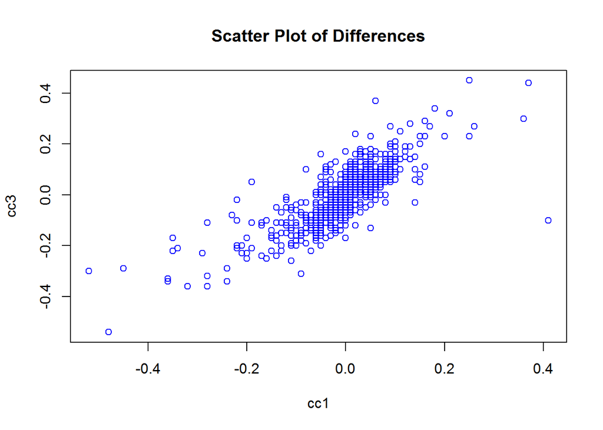

```r
cc1<-diff(rr1)
cc3<-diff(rr3)
plot(cc1,cc3,main="Scatter Plot of Differences", col = "blue")
```

The figure shows that the differences remain highly correlated

```r
clinreg_900 <-lm(cc3~cc1-1)
summary(clinreg_900)
```

```
##
## Call:
## lm(formula = cc3 ~ cc1 - 1)
##
## Residuals:
##      Min       1Q   Median       3Q      Max
## -0.51504 -0.03699 -0.00049  0.03025  0.30926
##
## Coefficients:
##     Estimate Std. Error t value Pr(>|t|)
## cc1  1.01229    0.02694   37.57   <2e-16 ***
## ---
## Signif. codes:  0 '***' 0.001 '**' 0.01 '*' 0.05 '.' 0.1 ' ' 1
##
## Residual standard error: 0.06372 on 899 degrees of freedom
## Multiple R-squared:  0.6109, Adjusted R-squared:  0.6105
## F-statistic:  1411 on 1 and 899 DF,  p-value: < 2.2e-16
```

```r
cresiduals_900 <- clinreg_900$residuals
```

Plot the residuals and their ACF

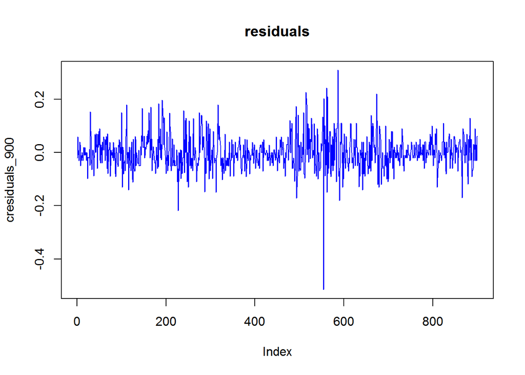

```r
plot(cresiduals_900,type ="l",main = "residuals",col = "blue")
```

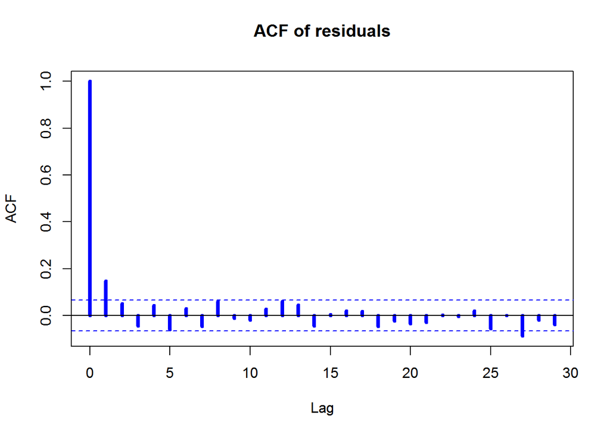

```r
acf(cresiduals_900,main = "ACF of residuals",col ="blue",lty=1 ,lwd = 4)
```

From the sample ACF of residuals, we identify an MA(1) model for the residuals and modify the linear regression model to $c_{t3}= \beta_2 c_{t1}+\epsilon_{t}$ $\epsilon_{t}= a_t-\theta_1a_{t-1}, t=2,\ldots,T,$ where $a_t$ assumed to be a white noise series.

Estimate MA(1) model and find the residuals

```r
ma1_900 <- armaFit(~ ma(1), data = cresiduals_900)
summary(ma1_900, which =  "all")
```

```
##
## Title:
##  ARIMA Modelling
##
## Call:
##  armaFit(formula = ~ma(1), data = cresiduals_900)
##
## Model:
##  ARIMA(0,0,1) with method: CSS-ML
##
## Coefficient(s):
##       ma1  intercept
##  0.134715   0.000826
##
## Residuals:
##       Min        1Q    Median        3Q       Max
## -0.529536 -0.035965 -0.003948  0.032554  0.295102
##
## Moments:
## Skewness Kurtosis
##   -0.120    6.742
##
## Coefficient(s):
##            Estimate  Std. Error  t value Pr(>|t|)
## ma1        0.134715    0.030782    4.376 1.21e-05 ***
## intercept  0.000826    0.002384    0.347    0.729
## ---
## Signif. codes:  0 '***' 0.001 '**' 0.01 '*' 0.05 '.' 0.1 ' ' 1
##
## sigma^2 estimated as: 0.003973
## log likelihood:       1210.67
## AIC Criterion:        -2415.34
```

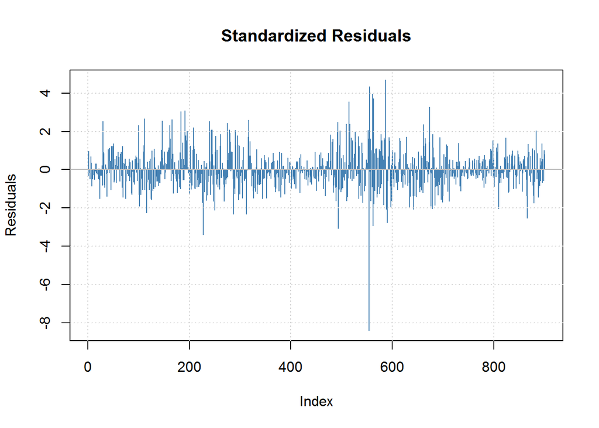

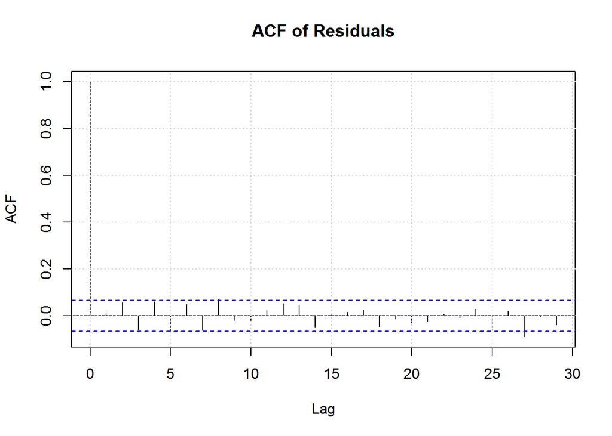

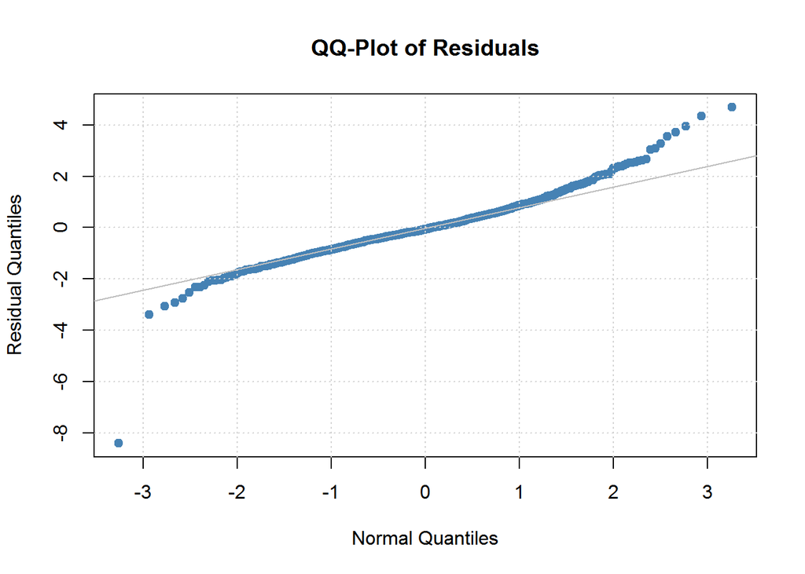

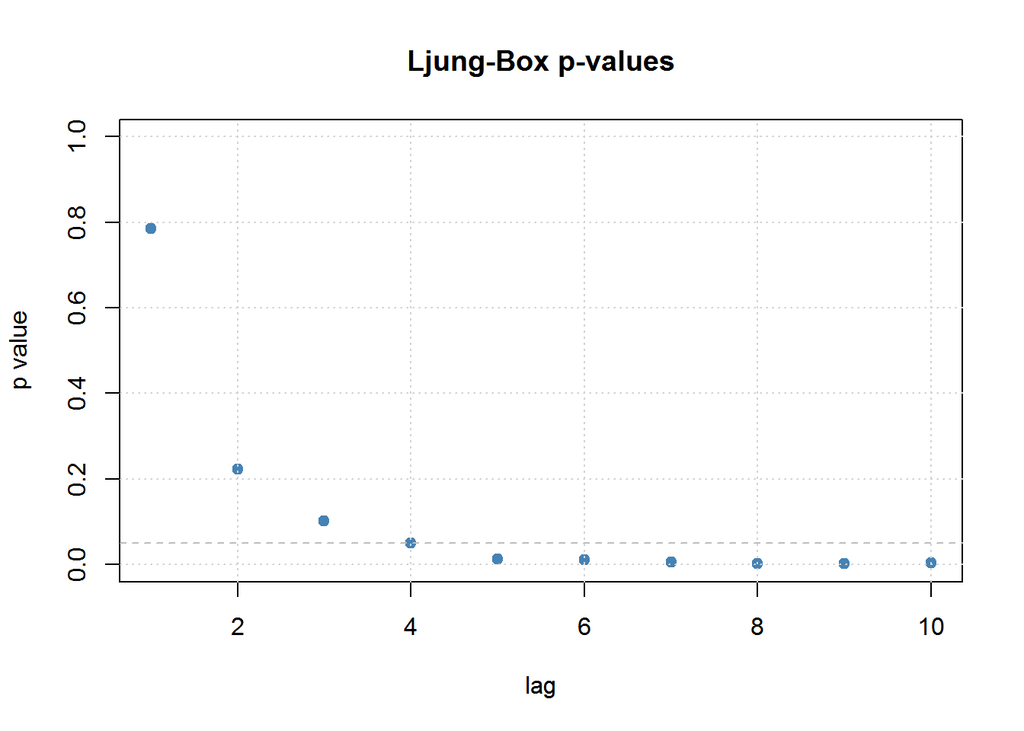

```
##
## Description:
##  Thu Jul 21 14:31:19 2016 by user: YURI
```

```r
ma1_900res <- residuals(ma1_900)
```

We estimated model of relationship between the weekly constant maturity 1-year and 3-year interest rate series

Build forecast for $r_3$ rate according this model

First, forecast $\epsilon_{t}$ ,$t=2,......T$, using MA(1) model.

```r
theta1_900 <-ma1_900@fit$coef[1]
a_t_900 <- theta1_900 *ma1_900res
```

Let $f_t$ be a forecast for $r_{t,3}$

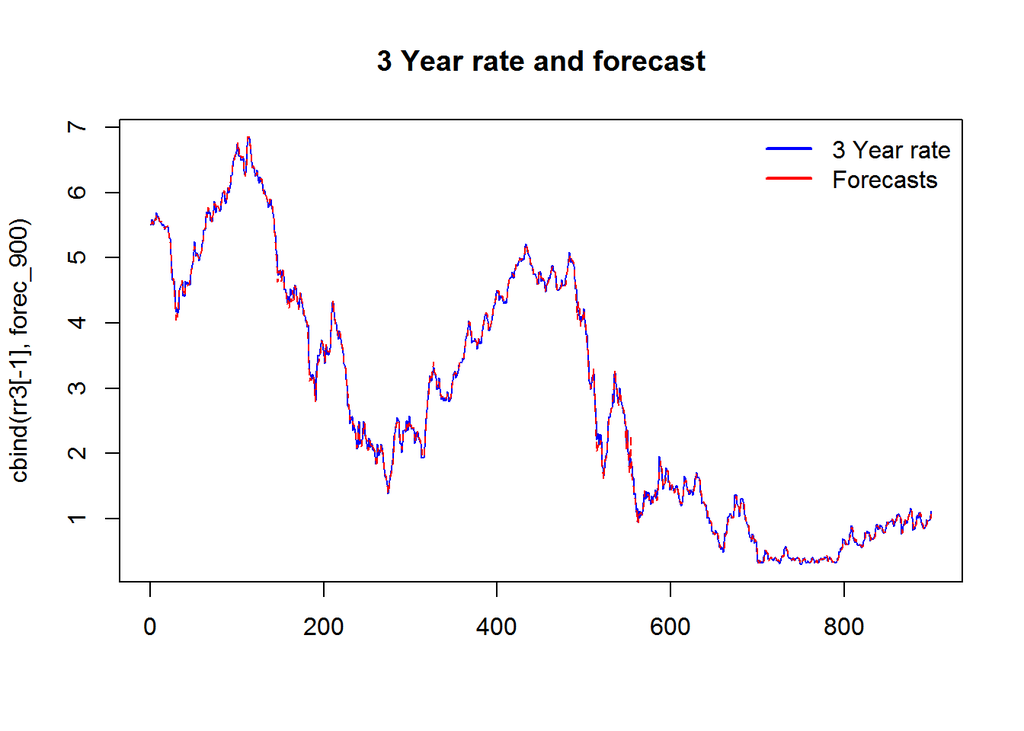

```r
x_3_900<-rr3[-length(rr3)]
forec_900 <- x_3_900 + clinreg_900$coefficients*cc1+a_t_900
matplot(cbind(rr3[-1],forec_900),type = "l",col = c("blue","red"),main= "3 Year rate and forecast")
legend("topright", c("3 Year rate","Forecasts"), lwd=2,col = c("blue","red"), bty="n")
```

Check the scatter plot of forecast differences versus the differenced 1-year yield

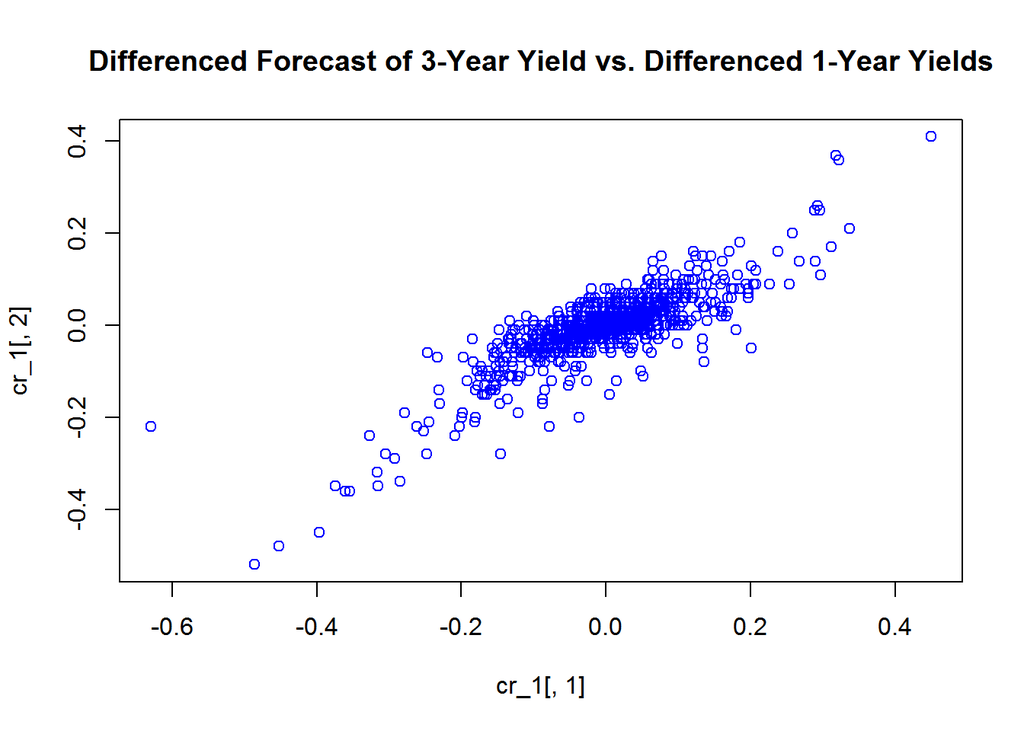

```r
difforec_900 <- diff(forec_900)
cr_1<-cbind(difforec_900,cc1[-1])
plot (cr_1[,1],cr_1[,2],col = "blue",main = "Differenced Forecast of 3-Year Yield vs. Differenced 1-Year Yields")
```

Compare the errors of the regression model with stationary residuals for 3-year rate of cointegration model

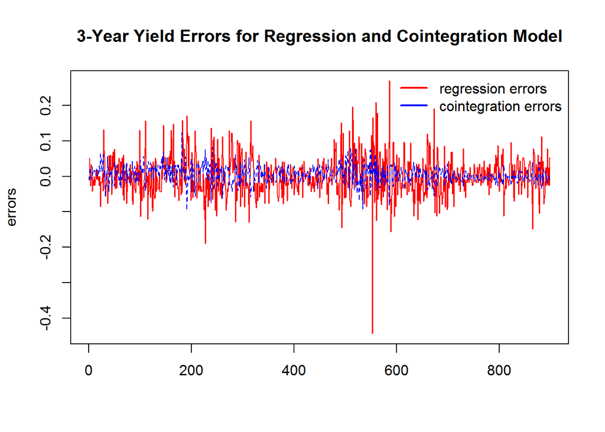

```r
linregerror_900 <- rr3[-1]-forec_900
errors<-cbind(linregerror_900[-1],cerror3)
matplot(errors,type ="l",col = c("red","blue"),main = "3-Year Yield Errors for Regression and Cointegration Model")
legend("topright", c("regression errors","cointegration errors"), lwd=2,col = c("red","blue"), bty="n")
```

The variance level of cointegration errors is lower than for errors of the regression model.

Check how errors of the two models are related to each other.

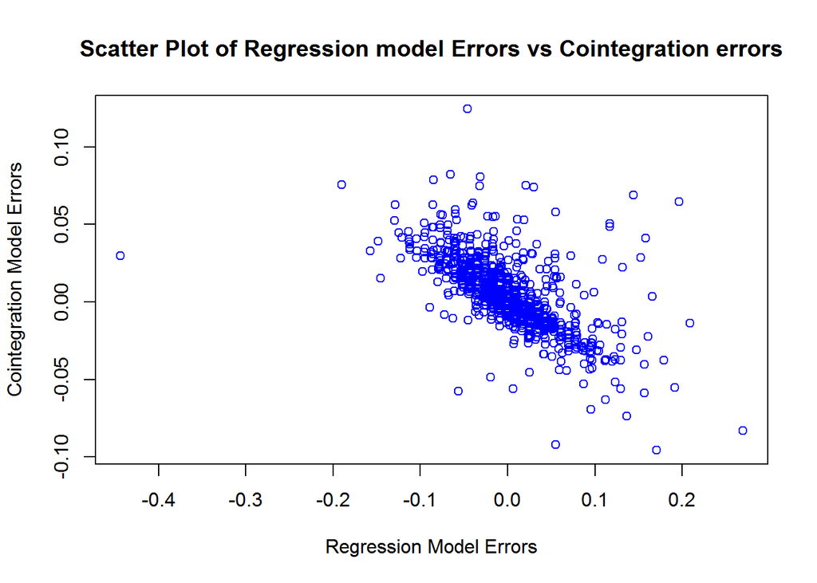

```r
plot(errors[,1],errors[,2],col = "blue",
     main = "Scatter Plot of Regression model Errors vs Cointegration errors",
     xlab="Regression Model Errors", ylab="Cointegration Model Errors")
```

The errors of the two models are negatively correlated.  
This suggests that by mixing the models together the error level may be reduced.